# ReMoTe Sensitivity Analyses

Laura White

12 May, 2022, 12:46

## Sensitivity analyses

Here we run the ReMoTe model. We first vary the proportion of the population at high risk of TB exposure and the probability of TB disease progression. In the latter, we consider one scenario with constant protection from progression (non-Ackley) and four scenarios with protection where we vary either the probability of progression with one infection or the rate that protection wanes with subsequent infection. Finally we consider the scenario where the difference between the ARI in the high and low risk groups varies between 4 and 8 (the main results have this set to 6).

### Results: changing proportion at low risk

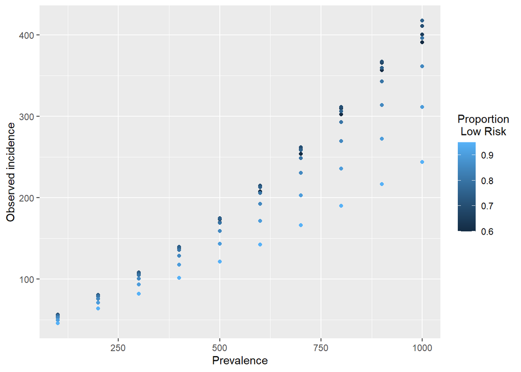

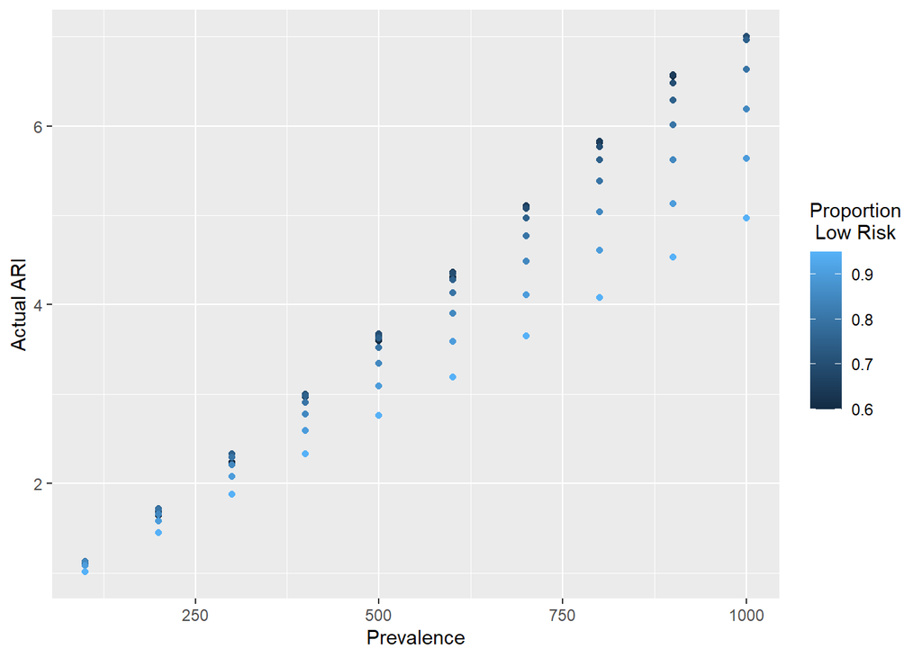

### Results: changing the risk of TB disease assumption

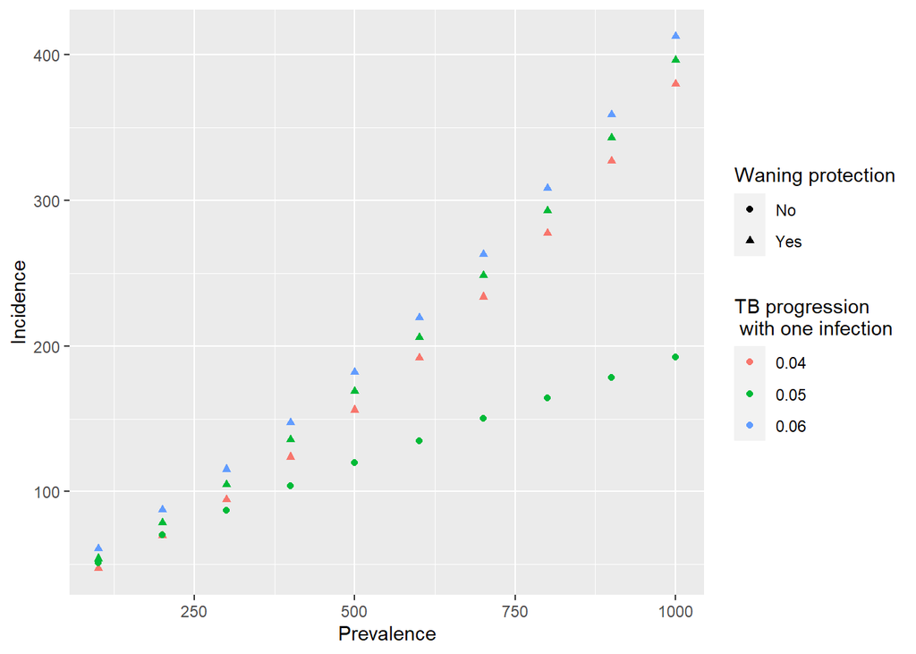

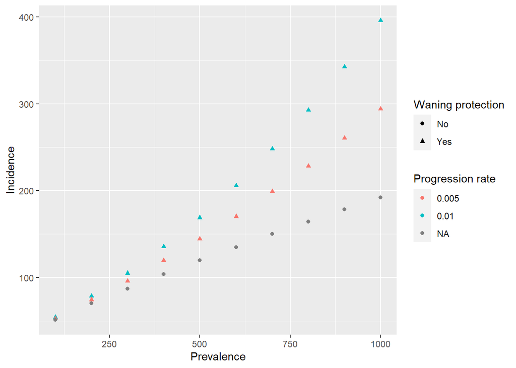

### Results: changing ratio between high and low risk ARI

We vary the ratio between ARIs for the high and low risk populations from 4 to 8. In the main analyses, this is assumed to be 6. For these scenarios, we maintain 80% of the population in the low risk group.

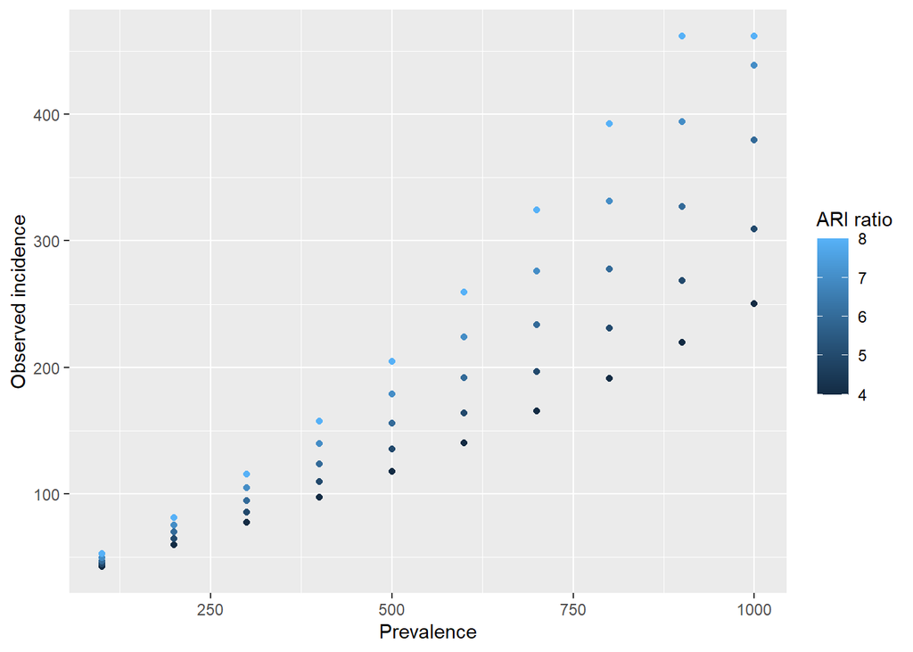

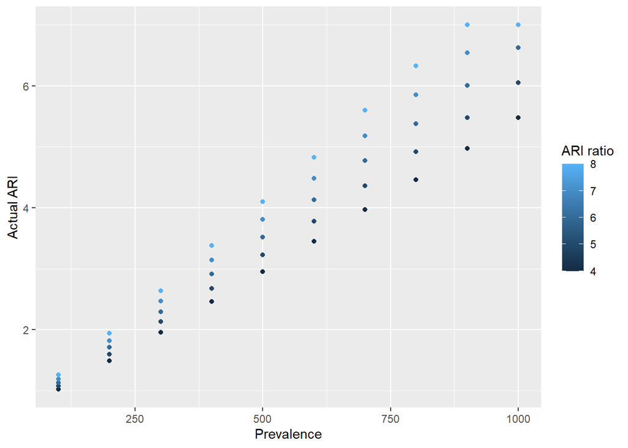